# Spotify_Final_Project

/——————————————————————————————————————————————————————————————- Title: Spotify Unwrapped Group: Jonah Landas, Ryan Freidhoff

Questions: Can we profile the playlist to see exactly what the typical song looks like? What are the strongest correlations within these songs, and what exactly is the backbone of a playlist?

/——————————————————————————————————————————————————————————————- Introduction: The following project will be aimed at discovering correlations and unique aspects of a custom playlist we made on Spotify. This is of interest as we would like to see if our analysis can profile what type of listeners we are and possibly suggest how to look for new songs based on our profiling of the typical song on the playlist. We will begin by describing the data, cleaning and reformatting the data, and then using visualization tools to recognize trends and patterns within the data before summarizing our findings in the conclusion. The visualization and findings section of this report will comprise of visualizations and summaries of the information learned from each visual.

Data: Data is from a playlist I have made on Spotify. The data contains date each song was produced, song duration, artist name, album name, song name, if it is a one-hit-wonder (Y/N), how many Spotify plays the song has, type of release, number of monthly listeners the main artist has, and a calculated column we added that is a ratio of the number of plays divided by the number of monthly listeners in an effort to normalize the values.

We will begin by loading in the .csv file. The chunk of code below reads the .csv file and creates the dataframe ‘spotify’ that we will be using throughout this project. Additionally, the column `Release.Date` is turned into type date and the `Duration` column is also transformed into minutes and seconds using lubridate.

```r
  library(rvest)
  library(lubridate)
  library(hms)
  csv <- read.csv("DS 202 Final Project - Data(Sheet1).csv")
  spotify <- as.data.frame(csv)
  spotify$`Release.Date` <- lubridate::mdy(spotify$`Release.Date`)
  spotify$Duration <- lubridate::ms(spotify$Duration)
  head(spotify)
```

```
##   Song.Number                            Song.Name         Artist
## 1           1                                 Wya?   Wifisfuneral
## 2           2                             Ease Off     YNG Martyr
## 3           3                         Sunny Nights        LeRoyce
## 4           4                                  Ivy    Frank Ocean
## 5           5 Laugh Now Cry Later (feat. Lil Durk) Drake,Lil Durk
## 6           6              What You Know Bout Love      Pop Smoke
##                                  Album Duration One.Hit.Wonder..Y.N.
## 1                                 Wya?    2M 4S                    Y
## 2                             Ease Off   2M 24S                    Y
## 3             The Sunny Nights Project    4M 1S                    Y
## 4                               Blonde    4M 9S                    N
## 5                  Laugh Now Cry Later   4M 21S                    N
## 6 Shoot For The Stars Aim For The Moon   2M 40S                    N
##   Type.of.Release Release.Date Monthly.Listeners      Plays
## 1          Single   2017-03-03            698084   52464951
## 2          Single   2020-08-28            780346   40032828
## 3           Album   2017-09-26            190907   13070873
## 4           Album   2016-08-20          33299216  754753577
## 5          Single   2020-08-14          80757806  950346345
## 6           Album   2020-10-02          21647886 1105260924
```

The first piece of investigation will be to dive into the number of plays each song has compared to the number of monthly listeners the main artist has. We will add a column that gives the ratio between the number of plays and the number of monthly listeners in the chunk below. We will name this new column `Plays.Listener.Ratio`.

```r
  library(dplyr)
```

```r
  library(tidyr)

  #This ratio of the plays by the monthly listeners (fan base) helps us normalize the values
  spotify$Plays.Listener.Ratio <- spotify$Plays / spotify$`Monthly.Listeners`

  #avgMonthlyListeners will be used later in some of the graphing
  avgMonthlyListeners <- mean(spotify$`Monthly.Listeners`)
  #avgMonthlyListeners

  #avgRatio will be used later for some of the graphing
  avgRatio <- mean(spotify$Plays.Listener.Ratio)
  #avgRatio

  #avgPlays will be used later for some of the graphing
  avgPlays <- mean(spotify$Plays)
  #avgPlays
```

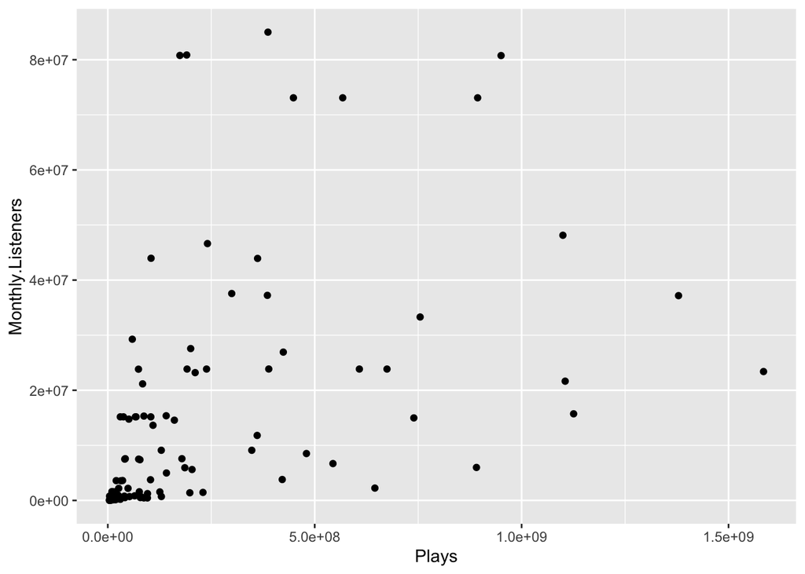

```r
  library(ggplot2)

  #This is our initial visualization of the plays by the monthly listeners in the form of a scatter plot
  plot1 <- ggplot(data = spotify, aes(x = `Plays`, y = `Monthly.Listeners`)) +
  geom_point()

  plot1
```

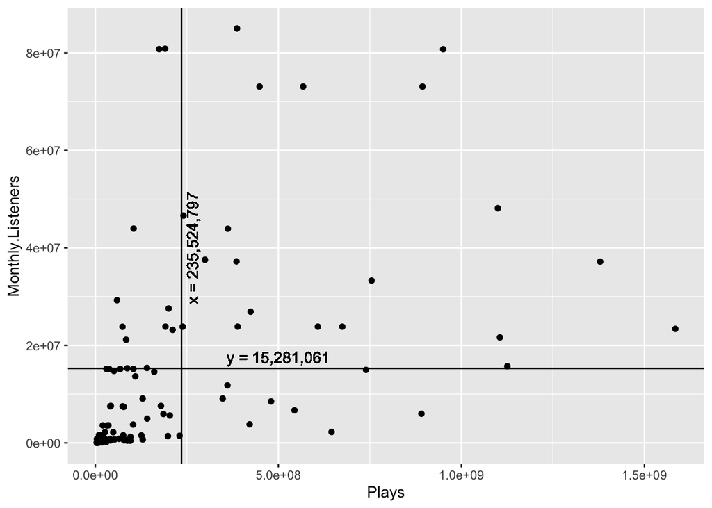

```r
  library(ggplot2)

  #Our second layer of visualization adds the avgPlays and avgMonthlyListeners to the graph
  plot2 <- ggplot(data = spotify, aes(x = `Plays`, y = `Monthly.Listeners`)) +
  geom_point() +
    geom_hline(aes(yintercept = avgMonthlyListeners)) +
    geom_vline(aes(xintercept = avgPlays)) +
    geom_text(aes(5e8, y= avgMonthlyListeners,label = "y = 15,281,061", vjust = -0.5)) +
    geom_text(aes(x= avgPlays, y=4e7,label = "x = 235,524,797", vjust = 1.5, angle = 90))

  plot2
```

We further the investigation by adding horizontal and vertical lines at the average number of monthly listeners and the average number of plays, respectively. This was done in an effort to see if there is a ‘average’ song based on these metrics alone. There are no songs particularly close to the intersection of the averages, so we will investigate if normalizing the number of plays by creating the previously mentioned plays to monthly listeners ratio will yield any interesting results.

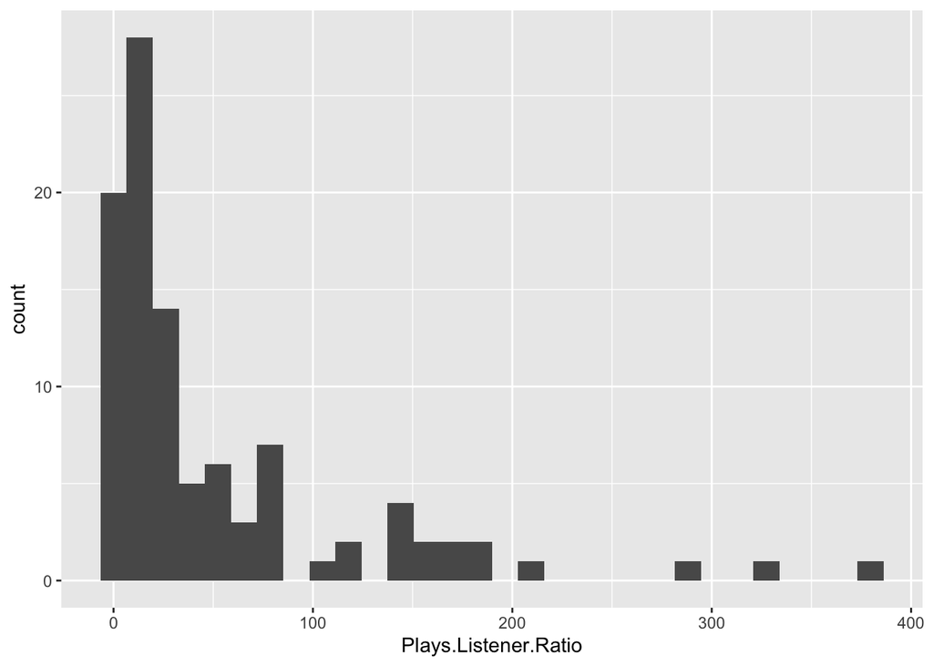

```r
  library(ggplot2)

  #We now use the normalized ratio calculated early to see the typical tatio of plays to fan base in this histogram
  plot3 <- ggplot(data = spotify, aes(x = Plays.Listener.Ratio)) +
    geom_histogram()

  plot3
```

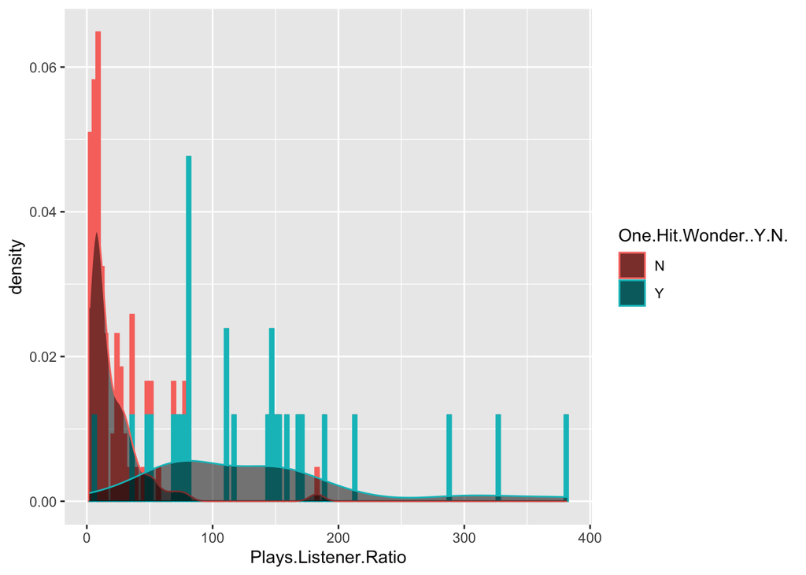

```r
  library(ggplot2)

  #We now add the get_density function to see the relative density of each ratio in terms of one hit wonder column
  plot5 <- ggplot(data = spotify, aes(x = Plays.Listener.Ratio,y= after_stat(density) ,fill= `One.Hit.Wonder..Y.N.`, color= `One.Hit.Wonder..Y.N.`)) +
  geom_histogram(binwidth = 3) +
  geom_density(alpha=.5, fill= "black")

  plot5
```

From the above graph, we can see that not only do one hit wonders have a much larger average plays to monthly listeners ratio, but the range is also far greater for the one hit wonder songs than the tight spread of the songs that are not one hit wonders. We used the geom_density fucntion to show the general makeup of each category, which emphasized the difference in the mean ratio of the one hit wonders compared to the songs that are not one hit wonders.

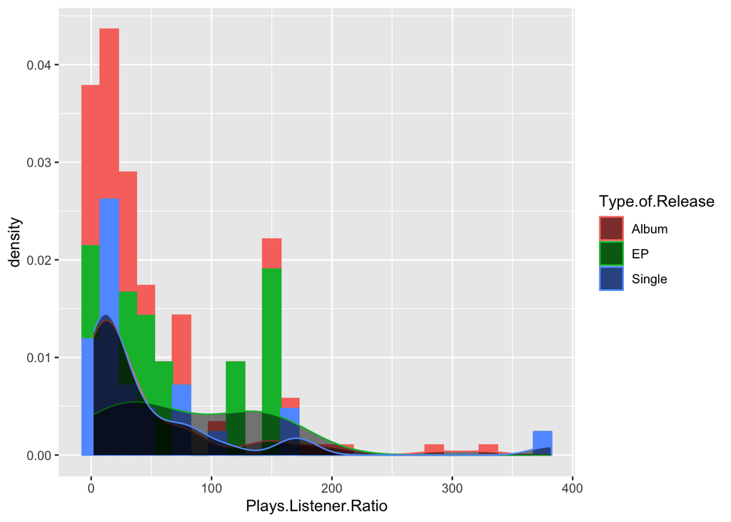

```r
  library(ggplot2)

  #We now add the get_density function to see the relative density of each ratio in terms of release type column
  plot6 <- ggplot(data = spotify, aes(x = Plays.Listener.Ratio,y= after_stat(density) ,fill= `Type.of.Release`, color= `Type.of.Release`)) +
  geom_histogram(binwidth = 15) +
  geom_density(alpha=0.5, fill="black")

  plot6
```

The above graph shows how the relative density of plays to monthly listeners ratio differs based on the type of release of the song. We can see that although there are fewer singles than albums, the overlay that shows a smooth function of the relative density shows that the singles and albums are nearly identical in terms of the plays to fan base ratio. Additionally, the songs released on EPs are mainly evenly accross a ratio less than 1 all the way to about 150.

These findings warranted further research as to what an EP is and why songs are released on EPs. After researching EPs, we found that EPs are often used by smaller artists as a cheap alternative to an album. EPs typically contain 3-6 songs, compared to albums that usually contain more than 10 songs. Based on the graph, we can see that the average ratio for the songs released on EPs is about 100, meaning that those songs are most likely also one hit wonders, backing the claim that smaller artists on this playlist are more likely to have a one hit wonder and as a result a larger plays to monthly listeners ratio due in part by the smaller fan base.

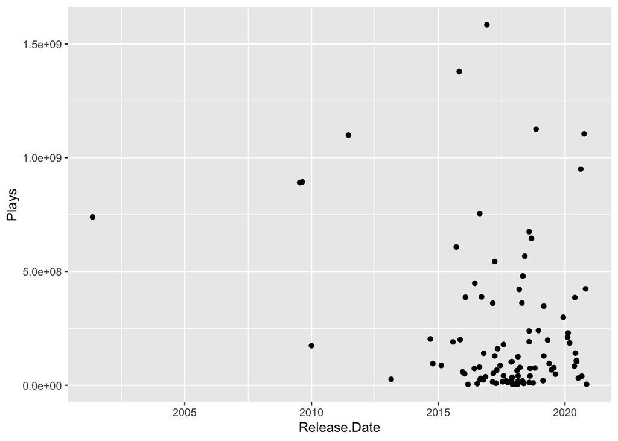

```r
  library(ggplot2)

  #We can now investigate whether the release date is correlated with the number of plays
  ggplot(data = spotify, aes(x = `Release.Date`, y = `Plays`)) +
    geom_point()
```

From the above scatter plot, we see that there is not a correlation between the number of plays and the release date. We will now look into if the plays to number of monthly listeners ratio is at all correlated to the song duration.

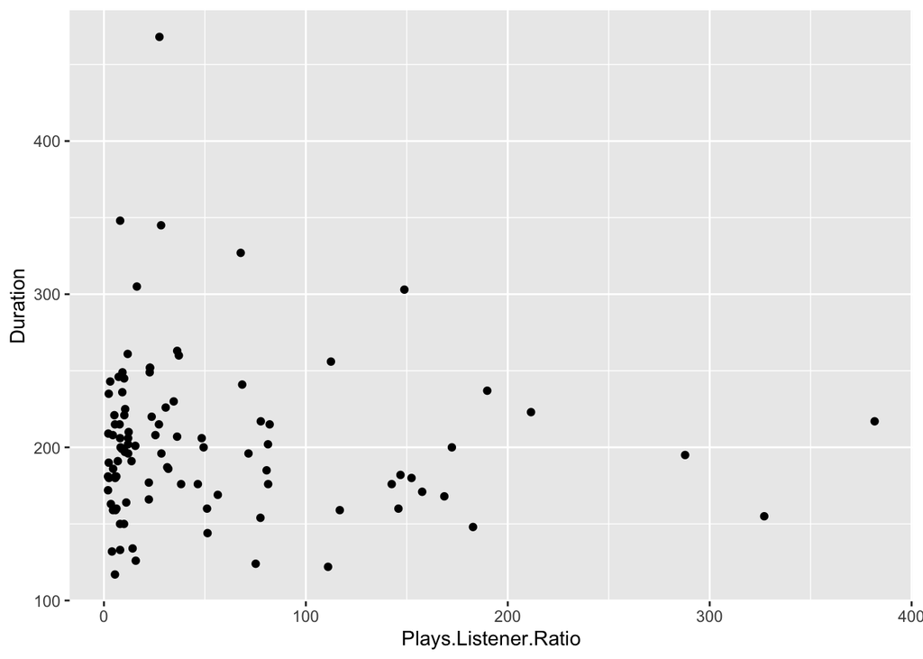

```r
  library(ggplot2)

  #We can now investigate whether the release date is correlated with the number of plays
  ggplot(data = spotify, aes(x = `Plays.Listener.Ratio`, y = `Duration`)) +
    geom_point()
```

```r
  library(modeest)
  library(lubridate)

  summary(spotify$Release.Date)
```

```
##         Min.      1st Qu.       Median         Mean      3rd Qu.         Max.
## "2001-05-15" "2016-10-07" "2017-12-20" "2017-07-16" "2018-10-28" "2020-11-06"
```

```r
  #The summary shows us that the average release date and the median release date are both in 2017 which agrees with the above scatter plot. The oldest song on this playlist is from 2001 and the most recent is from late 2020.
  mlv(month(spotify$Release.Date), method = "mfv")
```

```
## [1] 2
```

```r
  mlv(wday(spotify$Release.Date), method = "mfv")
```

```
## [1] 6
```

```r
  summary(spotify$Duration) #Shows the average duration of all songs
```

```
##        Min.     1st Qu.      Median        Mean     3rd Qu.        Max.
##    "1M 57S" "2M 51.75S"    "3M 18S" "3M 23.05S"  "3M 41.5S"    "7M 48S"
```

Based on the above code chunk, we can see that songs on this playlist are most likely to be produced in February, and the most often day of the week that the songs are released is Friday. We also see that the average song duration is 3 minutes and 23 seconds with the shortest song being only 1 minute and 57 seconds and the longest song being 7 minutes and 48 seconds, showing just how large the range of the duration is.

```r
  library(corrplot)
  library(lubridate)

  spotifyWork <- spotify
  spotifyWork$Seconds <- as.integer(seconds(spotifyWork$Duration))
  spotifyWork$Year <- as.integer(year(spotifyWork$Release.Date))
  spotifyNumeric <- spotifyWork[c(1, 9, 10, 11, 12, 13)]

  head(spotifyNumeric)
```

```
##   Song.Number Monthly.Listeners      Plays Plays.Listener.Ratio Seconds Year
## 1           1            698084   52464951             75.15564     124 2017
## 2           2            780346   40032828             51.30138     144 2020
## 3           3            190907   13070873             68.46723     241 2017
## 4           4          33299216  754753577             22.66581     249 2016
## 5           5          80757806  950346345             11.76786     261 2020
## 6           6          21647886 1105260924             51.05630     160 2020
```

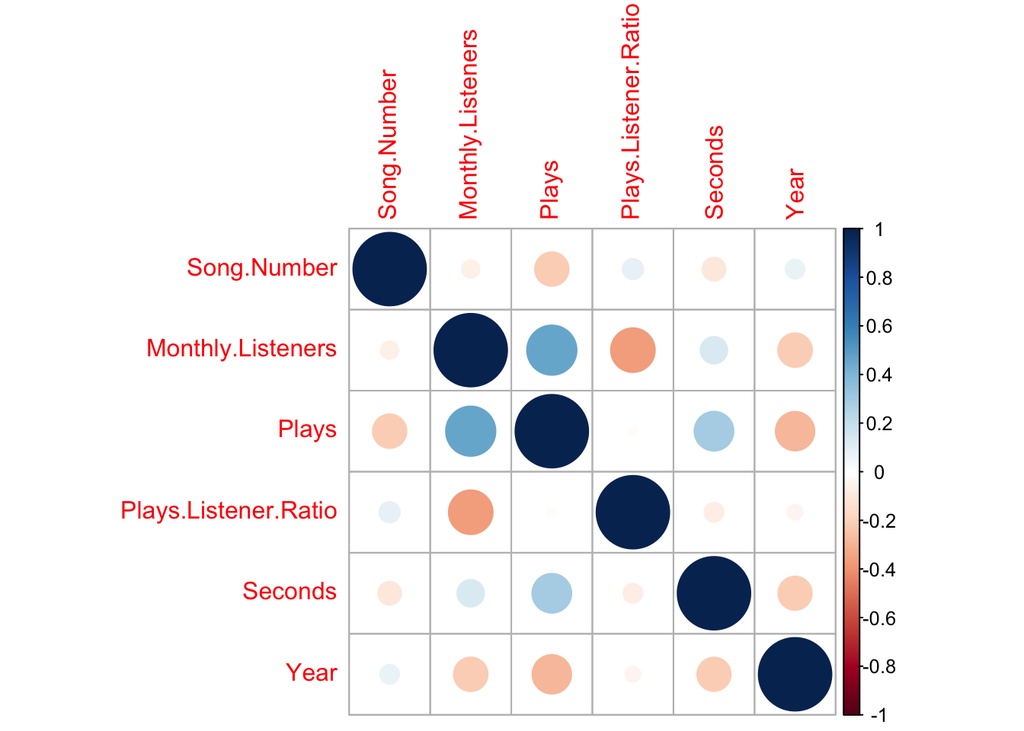

```r
  cor_data = cor(spotifyNumeric)
  corrplot(cor_data)
```

The above code chunk shows how we were able to create a correlation matrix of the data. We had to first isolate only the numeric columns of the data. We called this new data frame `spotifyNumeric`. We then created the actual matrix using the corrplot package. A few things to note from the matrix are that the `Plays` and `Plays.Listener.Ratio` columns are completely uncorrelated. The most positively correlated columns are the `Plays` and the `Monthly.Listeners` columns. The most negatively correlated columns are the `Plays.Listeners.Ratio` and `Monthly.Listeners` columns.

```r
  library(tidyverse)
  library(tidyr)

  length(unique(spotify$Artist))
```

```
## [1] 84
```

```r
  spotify2 <- separate(data = spotify, col = `Artist`, into = c("Artist1", "Artist2", "Artist3", "Artist4"), sep= ",")
  pivoted <- spotify2 %>% pivot_longer(cols = c("Artist1", "Artist2", "Artist3", "Artist4"),
                                      names_to = "Column Number", values_to = "Artist Name")
  #pivoted
  artistCount <- pivoted %>% count(`Artist Name`, sort= TRUE)
  head(artistCount)
```

```
## # A tibble: 6 × 2
##   `Artist Name`       n
##   <chr>           <int>
## 1 <NA>              267
## 2 blackbear           9
## 3 Mac Miller          6
## 4 Amine               4
## 5 Drake               3
## 6 Kota the Friend     3
```

```r
  #spotify2
```

```r
  #This shows the most played songs
  popularSongs <- spotify[order(spotify$Plays, decreasing = TRUE),]
  head(popularSongs)
```

```
##     Song.Number                            Song.Name
## 25           25                              Redbone
## 15           15                         Daddy Issues
## 100         100           Falling Down - Bonus Track
## 6             6              What You Know Bout Love
## 57           57     Give Me Everything (feat. Nayer)
## 5             5 Laugh Now Cry Later (feat. Lil Durk)
##                           Artist                                Album Duration
## 25              Childish Gambino                   "Awaken, My Love!"   5M 27S
## 15             The Neighbourhood                           Wiped Out!   4M 20S
## 100        Lil Peep,XXXTENTACION   Come Over When You're Sober, Pt. 2   3M 16S
## 6                      Pop Smoke Shoot For The Stars Aim For The Moon   2M 40S
## 57  Pitbull,AFROJACK,Ne-Yo,Nayer          Planet Pit (Deluxe Version)   4M 12S
## 5                 Drake,Lil Durk                  Laugh Now Cry Later   4M 21S
##     One.Hit.Wonder..Y.N. Type.of.Release Release.Date Monthly.Listeners
## 25                     N           Album   2016-12-02          23394403
## 15                     N           Album   2015-10-30          37177068
## 100                    Y           Album   2018-11-09          15723299
## 6                      N           Album   2020-10-02          21647886
## 57                     N           Album   2011-06-17          48136921
## 5                      N          Single   2020-08-14          80757806
##          Plays Plays.Listener.Ratio
## 25  1584603382             67.73429
## 15  1379184306             37.09772
## 100 1125632729             71.59011
## 6   1105260924             51.05630
## 57  1099726158             22.84579
## 5    950346345             11.76786
```

Issues Along the Way: Obtaining the data required a few hours of time due to the data set being custom. The solution was to be persistent and change some of the columns originally planned on being in the data set.

read_csv was being used originally and was working. Halfway through analysis, errors were thrown regarding read_csv() being an unknown function. The solution was using read.csv() instead and then updating the column names.

Date Released column format in .csv file was not compatible with lubridate. The solution was reformatting the excel worksheet to a different display of the dates and updating the .csv file version.

Some of the artists had characters that are not allowed in r in their name. The solution was to alter the name in the .csv file.